# Business Analytics - Tree Based Modeling

January 11, 2018

# **Bay Area Bikeshare at San-Francisco**

*Yarden Israeli, Amitai Serphos & Omer Klein*

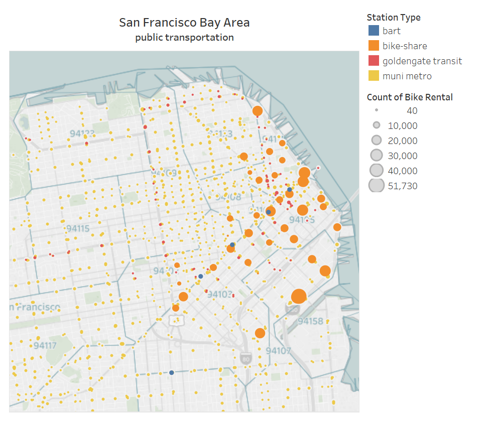

## **The Prime Objective**

### **Build prediction model for target station given rental information**

## **Business Potential**

- new marketing platform
  - **B2C** - market products and services for rider’s personal use
  - **B2B** - provide useful information to municipality/tourist sites/public tranportation like- traffic,popular stations

## **Challenges**

- Regression Tree Model Prediction
  - Degeneration of the coordinates
  - Most descriptions of decision tree learning assume a single target, but in our case- prediction of location requires two parameters - Lat-Lon (or East-North)
- Classification Tree Model Prediction
  - We have 37 classes (stations) - Tree based model has a limit of 32 classes

## **Our Approach**

- Regression Tree Model Prediction
  - convert GEO coordinates to UTM - this is a win-win situation ( more comfortable representation & easy to compute distances)
  - predict each variable separately, but we also show a method for multi target prediction
- Classification Tree Model Prediction
  - data reduction

## **Data Overview**

```r
train = read.csv("C:\\Users\\User\\Dropbox\\IDC\\Courses\\BusinessAnalytics\\project\\bike\\scriptsFlowR\\dataSets\\trainSuscribers2016_4RT1.csv", as.is = TRUE)
test = read.csv("C:\\Users\\User\\Dropbox\\IDC\\Courses\\BusinessAnalytics\\project\\bike\\scriptsFlowR\\dataSets\\testSuscribers2016_4RT1.csv", as.is = TRUE)

#reduce size of datasets
#set.seed(1)
#train = train[sample(150000),]
#test = test[sample(50000),]

#split to trainX & trainY
RT.trainX = train[-c(1,5,15,16,18)]
RT.trainY = train[-c(1,5,15,16,17)]
RT.test = test[-c(1,5,15,16,17,18)]

str(rbind(train,test))
```

```
## 'data.frame':    172966 obs. of  18 variables:
##  $ trip_id         : int  1059051 1311233 1072279 1105120 1258908 1122795 1236506 1143485 1294058 1218986 ...
##  $ start_station_id: int  60 74 59 70 69 69 57 45 48 54 ...
##  $ start_lat       : num  37.8 37.8 37.8 37.8 37.8 ...
##  $ start_lon       : num  -122 -122 -122 -122 -122 ...
##  $ duration_minutes: num  8.65 27.7 13.42 9.32 6.63 ...
##  $ start_dockcount : int  15 23 23 19 23 23 15 15 15 15 ...
##  $ month           : int  1 8 1 2 6 3 6 3 7 5 ...
##  $ day_status      : int  1 1 1 1 1 1 0 1 1 0 ...
##  $ hour            : int  18 7 18 7 8 7 15 17 9 14 ...
##  $ minDist_bart    : num  1429 267 433 1419 1405 ...
##  $ minDist_caltrain: num  3196.1 1929.2 2157.6 44 62.2 ...
##  $ minDist_ferry   : num  1352 171 2717 696 715 ...
##  $ minDist_muni    : num  1891 503 2427 1466 1470 ...
##  $ zipcode         : int  4555 94538 94610 94401 94303 4561 94105 4578 94105 94105 ...
##  $ bike_id         : int  677 675 378 332 274 659 420 451 488 455 ...
##  $ end_station_id  : int  77 65 50 47 57 50 62 74 54 68 ...
##  $ X_end           : num  552757 552603 553335 552525 552383 ...
##  $ Y_end           : num  4182643 4180582 4183287 4182569 4181767 ...
```

## **Regression Tree Method**

#### Model learning on Train data - X coordinate (East-West)

First run the Tree model for all predictors

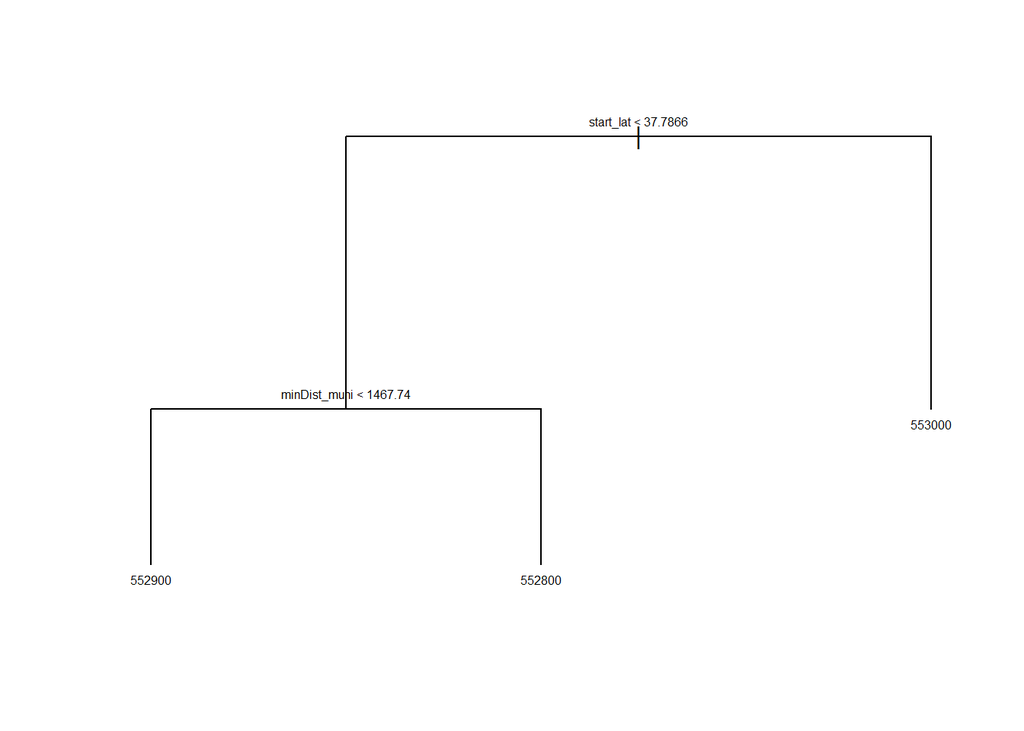

```r
#install.packages("tree")
library("tree")
RT.X = tree(X_end ~ . , data = RT.trainX)
plot(RT.X)
text(RT.X, pretty = 0, cex=0.5)
```

```r
summary(RT.X)
```

```
##
## Regression tree:
## tree(formula = X_end ~ ., data = RT.trainX)
## Variables actually used in tree construction:
## [1] "start_lat"    "minDist_muni"
## Number of terminal nodes:  3
## Residual mean deviance:  363400 = 4.715e+10 / 129700
## Distribution of residuals:
##    Min. 1st Qu.  Median    Mean 3rd Qu.    Max.
## -1849.0  -339.6   218.0     0.0   392.7  1119.0
```

Now, let’s try to estimate a more complex model that accounts another variables too.  
For example, change the control growth parameter *mindev* to 0.001  
(the deviance at the node under consideration has to be at least 0.1% of the root-node deviance)

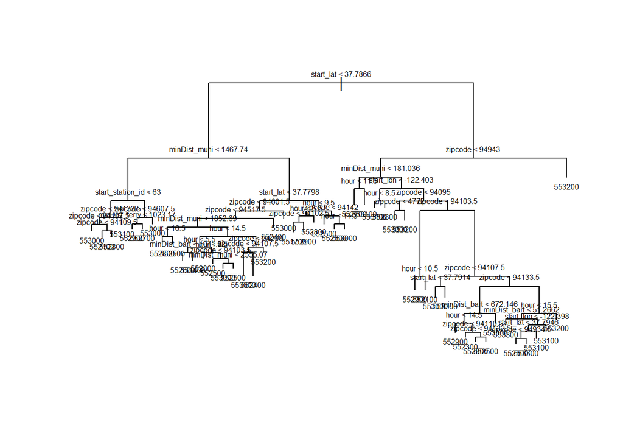

```r
RT.Xcomplex = tree(X_end ~ . , data = RT.trainX, mindev = 0.001)
plot(RT.Xcomplex)
text(RT.Xcomplex, pretty = 0, cex=0.5)
```

```r
summary(RT.Xcomplex)
```

```
##
## Regression tree:
## tree(formula = X_end ~ ., data = RT.trainX, mindev = 0.001)
## Variables actually used in tree construction:
## [1] "start_lat"        "minDist_muni"     "start_station_id"
## [4] "zipcode"          "minDist_ferry"    "hour"
## [7] "minDist_bart"     "start_lon"
## Number of terminal nodes:  48
## Residual mean deviance:  323000 = 4.188e+10 / 129700
## Distribution of residuals:
##     Min.  1st Qu.   Median     Mean  3rd Qu.     Max.
## -2129.00  -283.10    85.22     0.00   355.50  2517.00
```

#### Model evaluation on Test data - X coordinate (East-West)

First predict the X-axis value for the test data.

```r
prediction.RTxcomplex= predict(RT.Xcomplex,RT.test)
summary(prediction.RTxcomplex)
```

```
##    Min. 1st Qu.  Median    Mean 3rd Qu.    Max.
##  551369  552830  553013  552934  553050  553300
```

Now we can compute RMSE - square root of the mean of square residuals

```r
predictionErr.RTxcomplex = test$X_end - prediction.RTxcomplex
RSS = sum(predictionErr.RTxcomplex ^2)
MSE <- RSS/length(predictionErr.RTxcomplex)
RMSE.RTxcomplex <- sqrt(MSE)
RMSE.RTxcomplex
```

```
## [1] 572.3681
```

We can also compare between the models

```r
prediction.RTx = predict(RT.X,RT.test)
predictionErr.RTx = test$X_end - prediction.RTx
RSS = sum(predictionErr.RTx ^2)
MSE <- RSS/length(predictionErr.RTx)
RMSE.RTx <- sqrt(MSE)
RMSE.RTx
```

```
## [1] 601.3203
```

#### Model learning & Evaluation - Y coordinate (South-North)

Now we can run the same prediction process on the Y axis

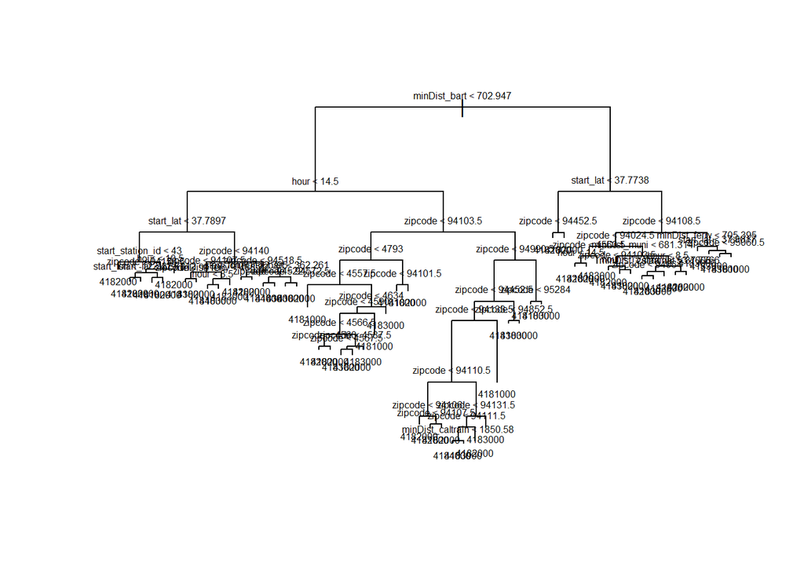

```r
RT.Ycomplex = tree(Y_end ~ . , data = RT.trainY, mindev = 0.001)
plot(RT.Ycomplex)
text(RT.Ycomplex, pretty = 0, cex=0.5)
```

```r
summary(RT.Ycomplex)
```

```
##
## Regression tree:
## tree(formula = Y_end ~ ., data = RT.trainY, mindev = 0.001)
## Variables actually used in tree construction:
## [1] "minDist_bart"     "hour"             "start_lat"
## [4] "start_station_id" "zipcode"          "start_lon"
## [7] "minDist_ferry"    "minDist_caltrain" "minDist_muni"
## Number of terminal nodes:  56
## Residual mean deviance:  649100 = 8.416e+10 / 129700
## Distribution of residuals:
##     Min.  1st Qu.   Median     Mean  3rd Qu.     Max.
## -2998.00  -492.90   -38.83     0.00   513.80  3060.00
```

Predict the Y-axis value for the test data and compute test error (in meters)

```r
prediction.RTycomplex = predict(RT.Ycomplex,RT.test)
predictionErr.RTycomplex = test$Y_end - prediction.RTycomplex
RSS = sum(predictionErr.RTycomplex ^2)
MSE <- RSS/length(predictionErr.RTycomplex)
RMSE.RTycomplex <- sqrt(MSE)
RMSE.RTycomplex
```

```
## [1] 806.7514
```

#### Model Evaluation - End-stations locations (XY coordinates)

Now we can compute the total error of end-stations prediction.  
(Achieved by Euclidean distance calculation in 2D)

```r
dist_2D = sqrt((predictionErr.RTxcomplex)^2 +(predictionErr.RTycomplex)^2)
RSS = sum(dist_2D^2)
MSE <- RSS/length(dist_2D)
RMSE.RTxy <- sqrt(MSE)
RMSE.RTxy
```

```
## [1] 989.1679
```

## **Random Forest Method**

#### Model learning on Train data - X coordinate (East-West)

First run the RF model for all predictors

```r
#install.packages("randomForest")
library(randomForest)
#RF.X = randomForest(X_end ~ . , data = RT.trainX, ntree = 50, do.trace=TRUE)
load("C:\\Users\\User\\Dropbox\\IDC\\Courses\\BusinessAnalytics\\project\\bike\\scriptsFlowR\\RF.X.RData")
RF.X
```

```
##
## Call:
##  randomForest(formula = X_end ~ ., data = RT.trainX, ntree = 50,      do.trace = TRUE)
##                Type of random forest: regression
##                      Number of trees: 50
## No. of variables tried at each split: 4
##
##           Mean of squared residuals: 268539
##                     % Var explained: 27.62
```

Now let’s check the contribution of each variable on predicting the target variable

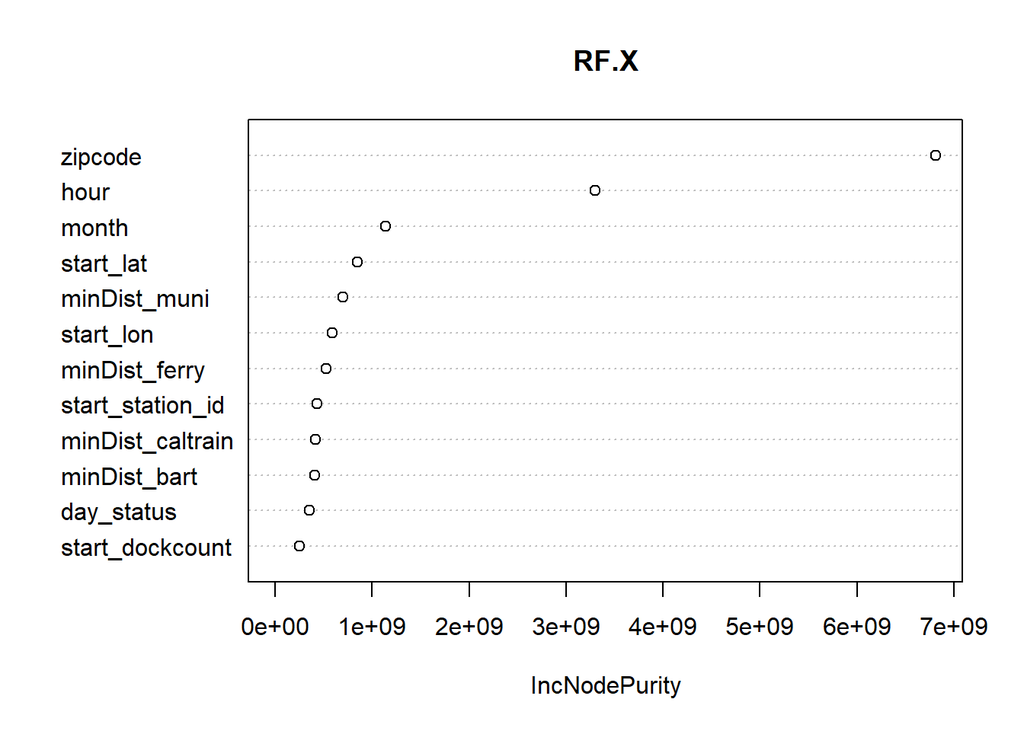

```r
varImpPlot(RF.X)
```

#### Model evaluation on Test data - X coordinate (East-West)

First predict the X-axis value for the test data.

```r
prediction.RFx <- predict(RF.X,RT.test)
summary(prediction.RFx)
```

```
##    Min. 1st Qu.  Median    Mean 3rd Qu.    Max.
##  551442  552799  552962  552943  553109  553664
```

Now we can compute RMSE - square root of the mean of square residuals

```r
predictionErr.RFx = test$X_end - prediction.RFx
RSS = sum(predictionErr.RFx ^2)
MSE <- RSS/length(predictionErr.RFx)
RMSE.RFx <- sqrt(MSE)
RMSE.RFx
```

```
## [1] 505.692
```

#### Model learning & Evaluation - Y coordinate (South-North)

Now we can run the same prediction process on the Y axis

```r
#RF.Y = randomForest(Y_end ~ . , data = RT.trainY, ntree = 50,do.trace=TRUE)
load("C:\\Users\\User\\Dropbox\\IDC\\Courses\\BusinessAnalytics\\project\\bike\\scriptsFlowR\\RF.Y.RData")
RF.Y
```

```
##
## Call:
##  randomForest(formula = Y_end ~ ., data = RT.trainY, ntree = 50,      do.trace = TRUE)
##                Type of random forest: regression
##                      Number of trees: 50
## No. of variables tried at each split: 4
##
##           Mean of squared residuals: 534647.4
##                     % Var explained: 42.17
```

Predict the Y-axis value for the test data and comute test error (in meters)

```r
prediction.RFy <- predict(RF.Y,RT.test)
predictionErr.RFy = test$Y_end - prediction.RFy
RSS = sum(predictionErr.RFy ^2)
MSE <- RSS/length(predictionErr.RFy)
RMSE.RFy <- sqrt(MSE)
RMSE.RFy
```

```
## [1] 713.5967
```

And again, a a significant improvement.

#### Model Evaluation - End-stations locations (XY coordinates)

Compute the total error of end-stations prediction. (Achieved by Euclidean distance calculation in 2D)

```r
dist_2D = sqrt((predictionErr.RFx)^2 +(predictionErr.RFy)^2)
RSS = sum(dist_2D^2)
MSE <- RSS/length(dist_2D)
RMSE.RFxy <- sqrt(MSE)
RMSE.RFxy
```

```
## [1] 874.6111
```

## **Multivariate Tree Method**

Most descriptions of decision tree learning assume a single target, which may be nominal (classification) or numerical (regression).  
**Blockeel, De Raedt, and Ramon (1998)** argued that decision tree learning can easily be extended towards the case of multi-target prediction, by extending the notion of class entropy or variance towards the multi-dimensional case.  
They define the variance of a set as the mean squared distance between any element of a set and a centroid of the set. Depending on the definition of distance, which could be Euclidean distance in a multidimensional target space, a decision tree will be built that gives accurate predictions for multiple target variables.

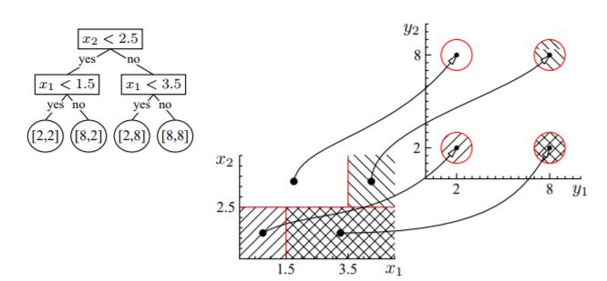

#### Reducing the data

For computational reasons, we took a 1,000 samples of rentals from training set and 250 random samples from testing set:

```r
set.seed(7)
inds_train = sample(1:nrow(train),1000)
inds_test = sample(1:nrow(test),250)
train_inputs_mat = as.matrix(train[inds_train,-c(1,5,15,16,17,18)])
train_outputs_mat = as.matrix(train[inds_train,c(17,18)])
test_inputs_mat = as.matrix(test[inds_test,-c(1,5,15,16,17,18)])
```

#### learn MVT model & get Prediction in 2D

```r
#install.packages("MultivariateRandomForest")
library(MultivariateRandomForest)
mvrPredict = build_forest_predict(train_inputs_mat,train_outputs_mat,1,12,5,test_inputs_mat)
str(as.data.frame(mvrPredict))
```

```
## 'data.frame':    250 obs. of  2 variables:
##  $ V1: num  552961 553690 553255 551307 553387 ...
##  $ V2: num  4183494 4181639 4181203 4181191 4182952 ...
```

#### compute test error

```r
predictionErr.MVT = sqrt((test$X_end[inds_test] - mvrPredict[,1])^2 + (test$Y_end[inds_test] - mvrPredict[,2]))
predictionErr.MVT = na.omit(predictionErr.MVT)
RSS = sum(predictionErr.MVT^2)
MSE <- RSS/length(predictionErr.MVT)
RMSE.MVT <- sqrt(MSE)
RMSE.MVT
```

```
## [1] 785.9917
```

#### compare to Tree method model with one variable predcition abillity

```r
RT.X1000 = tree(X_end ~ . , data = RT.trainX[inds_train,])
prediction.RTx1000 = predict(RT.X1000,RT.test[inds_test,])
predictionErr.RTx1000 = test$X_end[inds_test] - prediction.RTx1000

RT.Y1000 = tree(Y_end ~ . , data = RT.trainY[inds_train,])
prediction.RTy1000 = predict(RT.Y1000,RT.test[inds_test,])
predictionErr.RTy1000 = test$Y_end[inds_test] - prediction.RTy1000

predictionErr.RTx1000 = na.omit(predictionErr.RTx1000)
predictionErr.RTy1000 = na.omit(predictionErr.RTy1000)
dist_2D = sqrt((predictionErr.RTx1000)^2 +(predictionErr.RTy1000)^2)
RSS = sum(dist_2D^2)
MSE <- RSS/length(dist_2D)
RMSE.RTxy1000 <- sqrt(MSE)
RMSE.RTxy1000
```

```
## [1] 1130.524
```

## **KNN Classification Method**

```r
library(class)
#apply KNN with based on all features and predict end station ID
bike.train = train[-c(1,5,15,17,18)]
bike.test = test[-c(1,5,15,17,18)]
train.knn = bike.train[,-c(13)]
test.knn = bike.test[-c(13)]
trainClass.knn = train[,13]
knn.pred = knn(train.knn,test.knn,trainClass.knn,k = 10)
#compute KNN performance
knn.table = table(knn.pred,bike.test[,13])
#Accuracy
knn.accuracy = sum(diag(knn.table))/sum(knn.table)
knn.accuracy
```

```
## [1] 0.02728828
```

```r
#Misclassification
knn.misClassification = 1 - knn.accuracy
knn.misClassification
```

```
## [1] 0.9727117
```

## **Classification Tree Method**

#### Data Preprocessing

```r
bike.train = train[-c(1,5,15,17,18)]
bike.test = test[-c(1,5,15,17,18)]
# because of max 32 factors randomly remove start and end stations
set.seed(7)
start_stations_smaple = sample(unique(bike.train$start_station_id),10)
end_stations_smaple = sample(unique(bike.train$end_station_id),10)
bike.train = bike.train[(bike.train$start_station_id %in% start_stations_smaple),]
bike.train = bike.train[(bike.train$end_station_id %in% end_stations_smaple),]
bike.test = bike.test[(bike.test$start_station_id %in% start_stations_smaple),]
bike.test = bike.test[(bike.test$end_station_id %in% end_stations_smaple),]
```

convert charecter variables into factors in train

```r
bike.train$start_station_id = as.factor(bike.train$start_station_id)
bike.train$end_station_id = as.factor(bike.train$end_station_id)
```

convert charecter variables into factors in test

```r
bike.test$start_station_id = as.factor(bike.test$start_station_id)
bike.test$end_station_id = as.factor(bike.test$end_station_id)
```

#### Model learning on Train data

First run the Tree model for all predictors

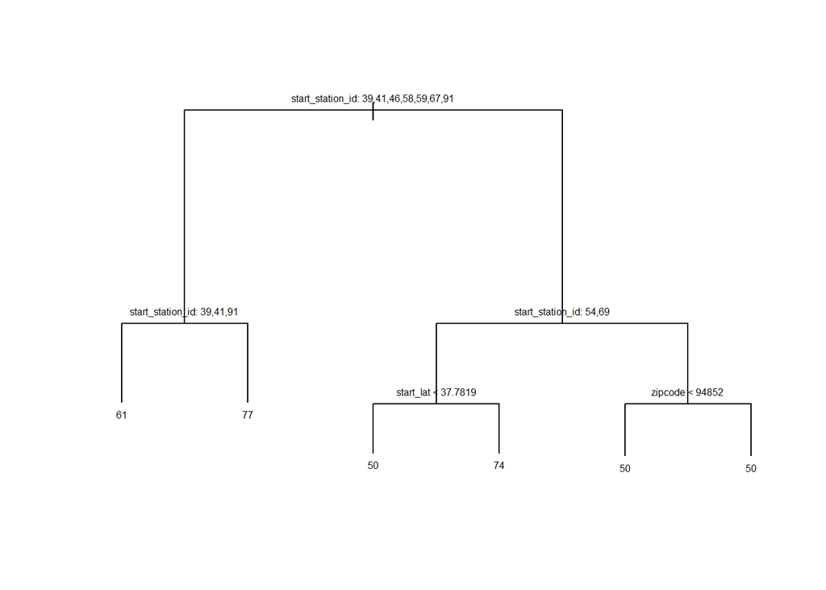

```r
library("tree")
bike_CART <- tree(end_station_id ~ . , data = bike.train)
plot(bike_CART)
text(bike_CART, pretty = 0, cex=0.5)
```

```r
summary(bike_CART)
```

```
##
## Classification tree:
## tree(formula = end_station_id ~ ., data = bike.train)
## Variables actually used in tree construction:
## [1] "start_station_id" "start_lat"        "zipcode"
## Number of terminal nodes:  6
## Residual mean deviance:  3.51 = 35080 / 9994
## Misclassification error rate: 0.6773 = 6773 / 10000
```

#### Model evaluation on Test data

```r
false_positive_fun <- function(table, x) {
sum(table[,x])-table[x,x]
}
false_negative_fun <- function(table, x) {
sum(table[x,])-table[x,x]
}
true_positive_fun <- function(table, x) {
table[x,x]
}
```

compute confusion matrix

```r
tree_test_results <- predict(bike_CART,bike.test[-c(13)],type="class")
table_tree = table(bike.test$end_station_id,tree_test_results)
table_tree
```

```
##     tree_test_results
##       47  50  61  66  68  73  74  76  77  90
##   47   0  78  24   0   0   0   5   0  71   0
##   50   0 687  43   0   0   0  96   0  47   0
##   61   0  69  64   0   0   0  40   0  68   0
##   66   0  83  72   0   0   0   0   0  28   0
##   68   0 102   9   0   0   0   5   0  60   0
##   73   0  12  60   0   0   0   7   0  13   0
##   74   0 433  37   0   0   0 108   0  77   0
##   76   0  87  20   0   0   0  19   0 129   0
##   77   0 405  39   0   0   0  11   0 156   0
##   90   0   5   3   0   0   0   1   0   3   0
```

```r
accuracy_tree = sum(diag(table_tree))/sum(table_tree)
#False Positive (When we predict Yes but its actuall No)
FP = sapply(1:10, false_positive_fun,  table = table_tree)
#False Negative (When we predict No but its actuall Yes)
FN = sapply(1:10, false_negative_fun,  table = table_tree)
#True Positive (When it's actually yes, how often does it predict yes?)
TP = sapply(1:10, true_positive_fun,  table = table_tree)
stations_id = colnames(table_tree)
confusion_tree = cbind(stations_id, TP, FN, FP)
confusion_tree
```

```
##       stations_id TP    FN    FP
##  [1,] "47"        "0"   "178" "0"
##  [2,] "50"        "687" "186" "1274"
##  [3,] "61"        "64"  "177" "307"
##  [4,] "66"        "0"   "183" "0"
##  [5,] "68"        "0"   "176" "0"
##  [6,] "73"        "0"   "92"  "0"
##  [7,] "74"        "108" "547" "184"
##  [8,] "76"        "0"   "255" "0"
##  [9,] "77"        "156" "455" "496"
## [10,] "90"        "0"   "12"  "0"
```

Accuracy - Tree for Classification

```r
accuracy_tree
```

```
## [1] 0.3098291
```

Recall - Tree for Classification

```r
confusionDF = as.data.frame(confusion_tree)
confusionDF$TP = as.numeric(as.character(confusionDF$TP))
confusionDF$FN = as.numeric(as.character(confusionDF$FN))
confusionDF$FP = as.numeric(as.character(confusionDF$FP))
recall4each = confusionDF$TP/(confusionDF$TP+confusionDF$FN)
confusionDF$recall = recall4each
confusionDF
```

```
##    stations_id  TP  FN   FP    recall
## 1           47   0 178    0 0.0000000
## 2           50 687 186 1274 0.7869416
## 3           61  64 177  307 0.2655602
## 4           66   0 183    0 0.0000000
## 5           68   0 176    0 0.0000000
## 6           73   0  92    0 0.0000000
## 7           74 108 547  184 0.1648855
## 8           76   0 255    0 0.0000000
## 9           77 156 455  496 0.2553191
## 10          90   0  12    0 0.0000000
```

```r
recall = mean(recall4each)
recall
```

```
## [1] 0.1472706
```

## **Classification Complex Tree Method**

#### Model learning on Train data

First run the Tree model for all predictors

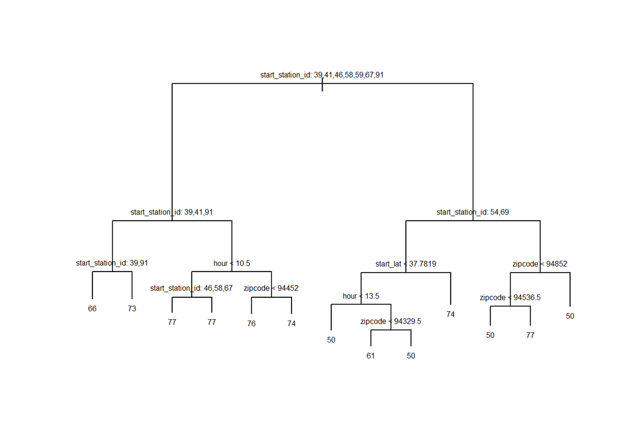

```r
library("tree")
bike_CART_complex <- tree(end_station_id ~ . , data = bike.train, mindev = 0.005)
plot(bike_CART_complex)
text(bike_CART_complex, pretty = 0, cex=0.5)
```

```r
summary(bike_CART_complex)
```

```
##
## Classification tree:
## tree(formula = end_station_id ~ ., data = bike.train, mindev = 0.005)
## Variables actually used in tree construction:
## [1] "start_station_id" "hour"             "zipcode"
## [4] "start_lat"
## Number of terminal nodes:  13
## Residual mean deviance:  3.311 = 33070 / 9987
## Misclassification error rate: 0.6331 = 6331 / 10000
```

#### Model evaluation on Test data

```r
false_positive_fun <- function(table, x) {
sum(table[,x])-table[x,x]
}
false_negative_fun <- function(table, x) {
sum(table[x,])-table[x,x]
}
true_positive_fun <- function(table, x) {
table[x,x]
}
```

compute confusion matrix

```r
ctree_test_results <- predict(bike_CART_complex,bike.test[-c(13)],type="class")
table_ctree = table(bike.test$end_station_id,ctree_test_results)
table_ctree
```

```
##     ctree_test_results
##       47  50  61  66  68  73  74  76  77  90
##   47   0  73   5  13   0  11   8  21  47   0
##   50   0 613  25  19   0  24 110  26  56   0
##   61   0  35  34  28   0  36  42  31  35   0
##   66   0  71   9  70   0   2   5  15  11   0
##   68   0  93   9   2   0   7   6  13  46   0
##   73   0   6   6  14   0  46   7  10   3   0
##   74   0 362   4  34   0   3 144  18  90   0
##   76   0  71   8  10   0  10  28  72  56   0
##   77   0 269  10  29   0  10  16  41 236   0
##   90   0   5   0   3   0   0   2   0   2   0
```

```r
accuracy_cx = sum(diag(table_ctree))/sum(table_ctree)
#False Positive (When we predict Yes but its actuall No)
FP = sapply(1:10, false_positive_fun,  table = table_ctree)
#False Negative (When we predict No but its actuall Yes)
FN = sapply(1:10, false_negative_fun,  table = table_ctree)
#True Positive (When it's actually yes, how often does it predict yes?)
TP = sapply(1:10, true_positive_fun,  table = table_ctree)
stations_id = colnames(table_ctree)
confusion_cx = cbind(stations_id, TP, FN, FP)
confusion_cx
```

```
##       stations_id TP    FN    FP
##  [1,] "47"        "0"   "178" "0"
##  [2,] "50"        "613" "260" "985"
##  [3,] "61"        "34"  "207" "76"
##  [4,] "66"        "70"  "113" "152"
##  [5,] "68"        "0"   "176" "0"
##  [6,] "73"        "46"  "46"  "103"
##  [7,] "74"        "144" "511" "224"
##  [8,] "76"        "72"  "183" "175"
##  [9,] "77"        "236" "375" "346"
## [10,] "90"        "0"   "12"  "0"
```

Accuracy - Complex Tree for Classification

```r
accuracy_cx
```

```
## [1] 0.3708791
```

Recall - Complex Tree for Classification

```r
confusionCX = as.data.frame(confusion_cx)
confusionCX$TP = as.numeric(as.character(confusionCX$TP))
confusionCX$FN = as.numeric(as.character(confusionCX$FN))
confusionCX$FP = as.numeric(as.character(confusionCX$FP))
recall4each = confusionCX$TP/(confusionCX$TP+confusionCX$FN)
confusionCX$recall = recall4each
confusionCX
```

```
##    stations_id  TP  FN  FP    recall
## 1           47   0 178   0 0.0000000
## 2           50 613 260 985 0.7021764
## 3           61  34 207  76 0.1410788
## 4           66  70 113 152 0.3825137
## 5           68   0 176   0 0.0000000
## 6           73  46  46 103 0.5000000
## 7           74 144 511 224 0.2198473
## 8           76  72 183 175 0.2823529
## 9           77 236 375 346 0.3862520
## 10          90   0  12   0 0.0000000
```

```r
recall = mean(recall4each)
recall
```

```
## [1] 0.2614221
```

## **Random Forest (Classification) Method**

#### Model learning on Train data

First run the RF model for all predictors

```r
library("randomForest")
set.seed(7)
bike_RF <- randomForest(end_station_id ~ . , data = bike.train)
bike_RF
```

```
##
## Call:
##  randomForest(formula = end_station_id ~ ., data = bike.train)
##                Type of random forest: classification
##                      Number of trees: 500
## No. of variables tried at each split: 3
##
##         OOB estimate of  error rate: 59.52%
## Confusion matrix:
##    47   50  61  66 68  73  74  76  77 90 class.error
## 47 64  241  29  36  0   6  24  68 153  0   0.8969404
## 50  0 2332  40  37  0   4 212  19  44  0   0.1324405
## 61  0  251 166  86  0   7  83  29  68  0   0.7594203
## 66  0  227  10 215  0   1  12  14  40  0   0.5857418
## 68 10  279  15  18 29   1  20  39  71  0   0.9398340
## 73  1   53  34  29  0 105  10  13  25  0   0.6111111
## 74  1 1332  22  54  0   6 544  31  94  0   0.7389635
## 76  8  231  48  40  1  12  72 178 130  0   0.7527778
## 77 11 1234  27  64  1   3  47  74 415  0   0.7787846
## 90  0   18   1  16  0   0   1   1  13  0   1.0000000
```

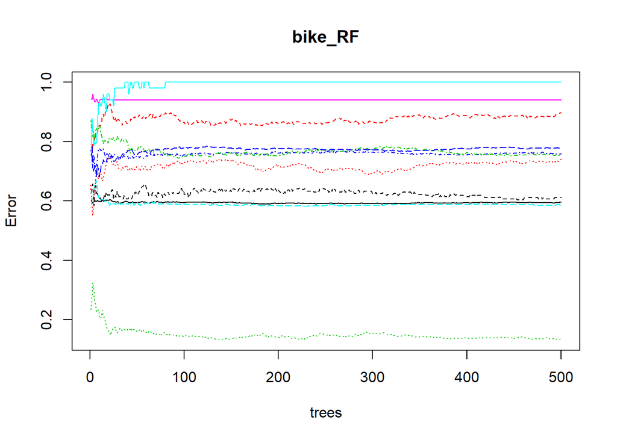

```r
plot(bike_RF)
```

```r
importance(bike_RF)
```

```
##                  MeanDecreaseGini
## start_station_id        101.19214
## start_lat                34.21995
## start_lon                99.64681
## start_dockcount          45.69747
## month                   104.08717
## day_status               36.86360
## hour                    327.47677
## minDist_bart             92.07870
## minDist_caltrain         94.67437
## minDist_ferry            70.97288
## minDist_muni             50.79746
## zipcode                 447.54925
```

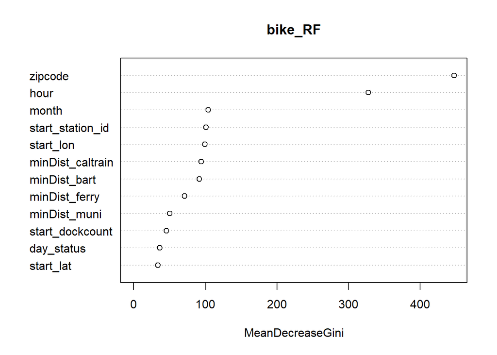

```r
varImpPlot(bike_RF)
```

#### Model evaluation on Test data

```r
RF_test_results <- predict(bike_RF,bike.test[-c(13)])
table_RF = table(bike.test$end_station_id,RF_test_results)
table_RF
```

```
##     RF_test_results
##       47  50  61  66  68  73  74  76  77  90
##   47  16  82   9  13   0   2   4  13  39   0
##   50   0 769  16  16   0   1  47   4  20   0
##   61   0  94  51  28   0   1  19  15  33   0
##   66   0  84   1  71   1   2   1   4  19   0
##   68   7 105   8   2   9   1   3  17  24   0
##   73   0  15   7  14   0  40   5   5   6   0
##   74   2 427   0  20   0   3 176   6  21   0
##   76   2  94  11  10   0   3  24  68  43   0
##   77   7 408  11  25   0   0  12  16 132   0
##   90   0   6   0   3   0   0   0   1   2   0
```

```r
accuracy_RF = sum(diag(table_RF))/sum(table_RF)
#False Positive (When we predict Yes but its actuall No)
FP = sapply(1:10, false_positive_fun,  table = table_RF)
#False Negative (When we predict No but its actuall Yes)
FN = sapply(1:10, false_negative_fun,  table = table_RF)
#True Positive (When it's actually yes, how often does it predict yes?)
TP = sapply(1:10, true_positive_fun,  table = table_RF)
stations_id = colnames(table_RF)
confusion_RF = cbind(stations_id, TP, FN, FP)
confusion_RF
```

```
##       stations_id TP    FN    FP
##  [1,] "47"        "16"  "162" "18"
##  [2,] "50"        "769" "104" "1315"
##  [3,] "61"        "51"  "190" "63"
##  [4,] "66"        "71"  "112" "131"
##  [5,] "68"        "9"   "167" "1"
##  [6,] "73"        "40"  "52"  "13"
##  [7,] "74"        "176" "479" "115"
##  [8,] "76"        "68"  "187" "81"
##  [9,] "77"        "132" "479" "207"
## [10,] "90"        "0"   "12"  "0"
```

Accuracy- Random Forest for Classification

```r
accuracy_RF
```

```
## [1] 0.4065934
```

Recall- Random Forest for Classification

```r
confusionDF_RF = as.data.frame(confusion_RF)
confusionDF_RF$TP = as.numeric(as.character(confusionDF_RF$TP))
confusionDF_RF$FN = as.numeric(as.character(confusionDF_RF$FN))
confusionDF_RF$FP = as.numeric(as.character(confusionDF_RF$FP))
recall4each_rf = confusionDF_RF$TP/(confusionDF_RF$TP+confusionDF_RF$FN)
confusionDF_RF$recall = recall4each_rf
confusionDF_RF
```

```
##    stations_id  TP  FN   FP     recall
## 1           47  16 162   18 0.08988764
## 2           50 769 104 1315 0.88087056
## 3           61  51 190   63 0.21161826
## 4           66  71 112  131 0.38797814
## 5           68   9 167    1 0.05113636
## 6           73  40  52   13 0.43478261
## 7           74 176 479  115 0.26870229
## 8           76  68 187   81 0.26666667
## 9           77 132 479  207 0.21603928
## 10          90   0  12    0 0.00000000
```

```r
recall_rf = mean(recall4each_rf)
recall_rf
```

```
## [1] 0.2807682
```